# Team 12

Kate Luo

Ian Wesley McDaniel

David Tabert

Christopher Carlevato

2/10/2020

# 8.3.1 Fitting Classification Trees

#### 1. Data

The `tree` library is used to construct classification and regression trees. Since Sales is a continuous variable, we have to recode and store it as a binary variable. We use the `ifelse()` function to create a variable, called `High`, which takes on a value of `Yes` if the `Sales` variable exceeds 8 - otherwise it takes on a value of `No`.

```r
library(tree)
library(ISLR)
attach(Carseats)
head(Carseats)
```

```
##   Sales CompPrice Income Advertising Population Price ShelveLoc Age Education
## 1  9.50       138     73          11        276   120       Bad  42        17
## 2 11.22       111     48          16        260    83      Good  65        10
## 3 10.06       113     35          10        269    80    Medium  59        12
## 4  7.40       117    100           4        466    97    Medium  55        14
## 5  4.15       141     64           3        340   128       Bad  38        13
## 6 10.81       124    113          13        501    72       Bad  78        16
##   Urban  US
## 1   Yes Yes
## 2   Yes Yes
## 3   Yes Yes
## 4   Yes Yes
## 5   Yes  No
## 6    No Yes
```

```r
High  <- ifelse(Sales <= 8, "No", "Yes")
head(High)
```

```
## [1] "Yes" "Yes" "Yes" "No"  "No"  "Yes"
```

To integrate this new variable, we use the `data.frame()` function to merge `High` with the rest of the `Carseats` data.

```r
Carseats <- data.frame(Carseats, High)
head(Carseats)
```

```
##   Sales CompPrice Income Advertising Population Price ShelveLoc Age Education
## 1  9.50       138     73          11        276   120       Bad  42        17
## 2 11.22       111     48          16        260    83      Good  65        10
## 3 10.06       113     35          10        269    80    Medium  59        12
## 4  7.40       117    100           4        466    97    Medium  55        14
## 5  4.15       141     64           3        340   128       Bad  38        13
## 6 10.81       124    113          13        501    72       Bad  78        16
##   Urban  US High
## 1   Yes Yes  Yes
## 2   Yes Yes  Yes
## 3   Yes Yes  Yes
## 4   Yes Yes   No
## 5   Yes  No   No
## 6    No Yes  Yes
```

#### 2. Construct Classifiction with Tree

We now use the `tree()`function to fit a classification tree in order to predict `High` using all variables but `Sales`. The syntax of the `tree()` function is quite similar to that of the `lm()` function.

```r
tree.carseats <- tree(High~.-Sales, Carseats)
summary(tree.carseats)
```

```
##
## Classification tree:
## tree(formula = High ~ . - Sales, data = Carseats)
## Variables actually used in tree construction:
## [1] "ShelveLoc"   "Price"       "Income"      "CompPrice"   "Population"
## [6] "Advertising" "Age"         "US"
## Number of terminal nodes:  27
## Residual mean deviance:  0.4575 = 170.7 / 373
## Misclassification error rate: 0.09 = 36 / 400
```

The `summary()` function lists the variables that are used as internal nodes in the tree, the number of terminal (ending) nodes and the training error rate. In this case, the training error rate is 9%. The *residual mean deviance* reported is simply the deviance divided by n-|T0| (T0 refers to the number of terminal nodes), which in this case is 400-27 = 373.

We use the `plot()` function to display the tree structure and the `text()` function to display the nodes labels. The argument `pretty=0` instructs `R` to include the category names for any qualitative predictors, rather than simply displaying a letter for each category.

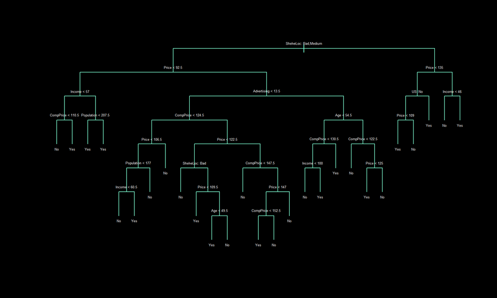

```r
par(bg = 'black')
plot(tree.carseats, type = 'uniform', col = 'aquamarine')
text(tree.carseats, pretty = 0, cex = .42, col = 'white')
```

The most important indicator of `Sales` appears to be `shelving location`, and the first branch differentiates `Good` locations (to the right) from `Bad` and `Medium` locations.

```r
tree.carseats
```

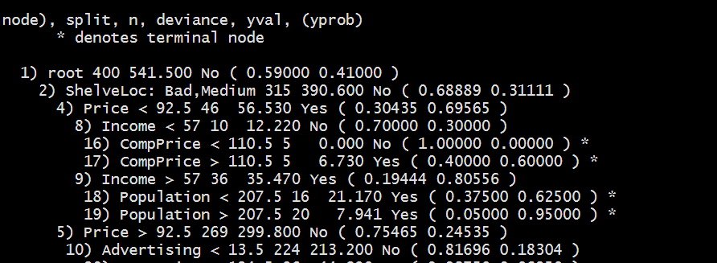

If we just type the name of the tree object, `R` prints output corresponding to each branch of the tree. `R` displays the split criterion, the number of observations in that branch, the deviance and the overall prediction for the branch(`Yes` or `No`). Branches that lead to terminal nodes are indicated using asterisks.

#### 3. Estimate the Test Error

In this step, we split the observations into a training set and a test set, build the tree using the training set and evaluate its performance on the test data. The `predict()` function can be used for this purpose. The argument `type="class"` instructs `R` to return the actual class prediction. This approach leads to correct predictions for around 69% of the locations in the test data set.

```r
set.seed(1011)
train <- sample(1:nrow(Carseats), 250)
Carseats.test <- Carseats[-train,]
High.test <- High[-train]
tree.carseats <- tree(High~.-Sales, Carseats, subset = train)
tree.pred <- predict(tree.carseats, Carseats.test, type = "class")
table(tree.pred, High.test)
```

```
##          High.test
## tree.pred No Yes
##       No  58  20
##       Yes 27  45
```

```r
(58+45)/150
```

```
## [1] 0.6866667
```

#### 4. Perform Cross-validation

`cv.tree()` determines the optimal level of tree complexity; cost complexity pruning is used in order to select a sequence of trees for consideration. We use the argument `FUN= prune.misclass` to indicate that we want the classification error rate to guide the cross-validation and pruning process, rather than the default for the `cv.tree()` function, which is deviance.

```r
cv.carseats <- cv.tree(tree.carseats, FUN = prune.misclass)
names(cv.carseats)
```

```
## [1] "size"   "dev"    "k"      "method"
```

```r
cv.carseats
```

```
## $size
##  [1] 23 17 16 14 10  8  6  5  4  2  1
##
## $dev
##  [1]  62  62  60  61  69  81  79  81  81  81 100
##
## $k
##  [1] -Inf  0.0  1.0  1.5  2.0  3.0  3.5  5.0  6.0  7.0 27.0
##
## $method
## [1] "misclass"
##
## attr(,"class")
## [1] "prune"         "tree.sequence"
```

The `cv.tree()` function reports the number of terminal nodes of each tree considered (size) as well as the corresponding error rate and the value of the cost-complexity parameter used.  
`dev` corresponds to the cross-validation error rate in this instance. The tree with 16 terminal nodes results in the lowest cross-validation error rate, with 60 cross-validation errors.

#### 5. Cross-validation Plot and Predict

Plot the error rate as a function of both `size` and `K`

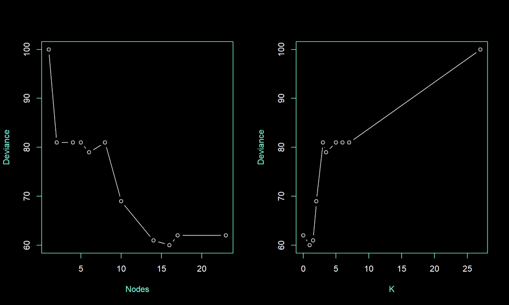

```r
par(mfrow=c(1,2), bg = 'black')

plot(cv.carseats$size, cv.carseats$dev, type = 'b', col = 'white', axes = FALSE, xlab = "", ylab = "")
box(col="aquamarine")
axis(1, col = "aquamarine", col.ticks = "aquamarine", col.axis = "white", cex.axis = 1)
axis(2, col = "aquamarine", col.ticks = "aquamarine", col.axis = "white", cex.axis = 1)
mtext("Nodes", side = 1, line = 3, col = "aquamarine", cex = 1)
mtext("Deviance", side = 2, line = 3, col = "aquamarine", cex = 1)
plot(cv.carseats$k, cv.carseats$dev, type = 'b', ylab = '', xlab = '', col = 'white')
box(col="aquamarine")
axis(1, col = "aquamarine", col.ticks = "aquamarine", col.axis = "white", cex.axis = 1)
axis(2, col = "aquamarine", col.ticks = "aquamarine", col.axis = "white", cex.axis = 1)
mtext("K", side = 1, line = 3, col = "aquamarine", cex = 1)
mtext("Deviance", side = 2, line = 3, col = "aquamarine", cex = 1)
```

We now apply the `prune.misclass()` function in order to prune the tree to obtain its 16-node variant.

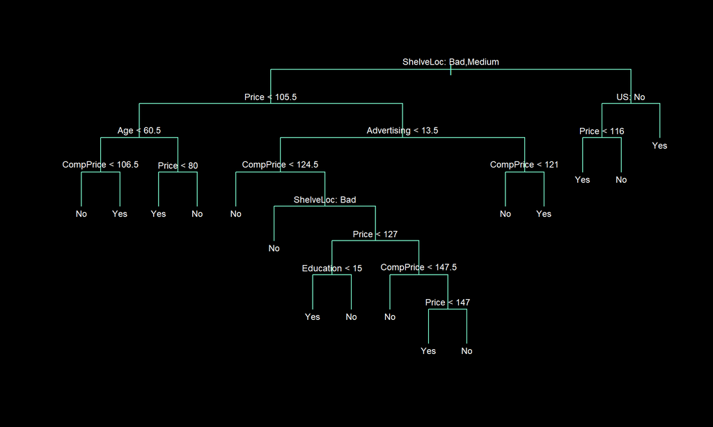

```r
par(bg = 'black')
prune.carseats <- prune.misclass(tree.carseats, best = 16)
plot(prune.carseats, type = 'uniform', col = 'aquamarine')
text(prune.carseats, pretty = 0, cex = .75, col = 'white')
```

```r
tree.pred<- predict(prune.carseats, Carseats.test, type = "class")
table(tree.pred, High.test)
```

```
##          High.test
## tree.pred No Yes
##       No  59  18
##       Yes 26  47
```

```r
(59+47)/150
```

```
## [1] 0.7066667
```

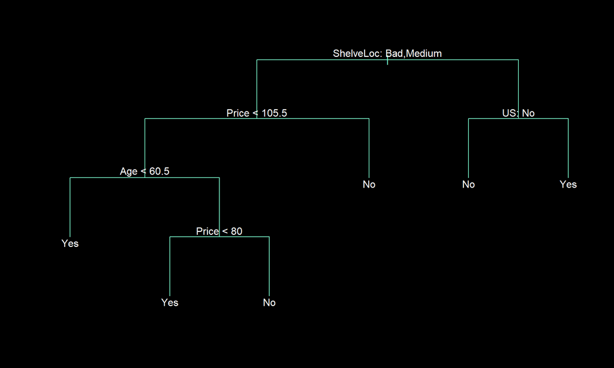

```r
prune.carseats <- prune.misclass(tree.carseats, best = 6)
par(bg = 'black')
plot(prune.carseats, type = 'uniform', col = 'aquamarine')
text(prune.carseats, pretty = 0, col = 'white')
```

```r
tree.pred <- predict(prune.carseats, Carseats.test, type = "class")
table(tree.pred, High.test)
```

```
##          High.test
## tree.pred No Yes
##       No  70  27
##       Yes 15  38
```

```r
(70+38)/150
```

```
## [1] 0.72
```